# Project: Investigate a Movie Dataset

- Introduction
- Data Wrangling
- Exploratory Data Analysis
- Conclusions

## Introduction

The aim of this project is to run this dataset to produce meaningful and accurate inferences about movies released between 1960 and 2015. Each row contains information about a speific movie on which we would explore.

In this report, we would answer a few questions:

1. Which movies have the highest profit and also lowest profit?
2. Which movie has the highest budget?
3. Which movie has the highest runtime?
4. Which movie has the highest popularity?
5. Is the popularity of a movie related to its profits?
6. Which year has the highest profits?
7. Which year has the highest release of movies?
8. Top 10 Production Companies With Higher Number Of Releases?
9. Which genres have the highest releases of movies?
10. What Kind Of Properties Are Associated With Movies With High Revenue?
11. Top 10 directors who directs most Movies?
12. How is popularity trending over time?

> **NB** Profit is a calculated column, which was calculated by subtacting budget from revenue obtained.

```python
import pandas as pd
import numpy as np
import matplotlib.pyplot as plt
import seaborn as sns
%matplotlib inline
```

## Data Wrangling

### General Properties

```python
# Load the data
df=pd.read_csv('tmdb-movies.csv')
df.head(1)
```

|  | id | imdb_id | popularity | budget | revenue | original_title | cast | homepage | director | tagline | ... | overview | runtime | genres | production_companies | release_date | vote_count | vote_average | release_year | budget_adj | revenue_adj |
| --- | --- | --- | --- | --- | --- | --- | --- | --- | --- | --- | --- | --- | --- | --- | --- | --- | --- | --- | --- | --- | --- |
| 0 | 135397 | tt0369610 | 32.985763 | 150000000 | 1513528810 | Jurassic World | Chris Pratt\|Bryce Dallas Howard\|Irrfan Khan\|Vi... | http://www.jurassicworld.com/ | Colin Trevorrow | The park is open. | ... | Twenty-two years after the events of Jurassic ... | 124 | Action\|Adventure\|Science Fiction\|Thriller | Universal Studios\|Amblin Entertainment\|Legenda... | 6/9/15 | 5562 | 6.5 | 2015 | 1.379999e+08 | 1.392446e+09 |

1 rows × 21 columns

```python
# finding the total number of columns and rows in the data
df.shape
```

```
(10866, 21)
```

```python
df.info()
```

```
<class 'pandas.core.frame.DataFrame'>
RangeIndex: 10866 entries, 0 to 10865
Data columns (total 21 columns):
 #   Column                Non-Null Count  Dtype
---  ------                --------------  -----
 0   id                    10866 non-null  int64
 1   imdb_id               10856 non-null  object
 2   popularity            10866 non-null  float64
 3   budget                10866 non-null  int64
 4   revenue               10866 non-null  int64
 5   original_title        10866 non-null  object
 6   cast                  10790 non-null  object
 7   homepage              2936 non-null   object
 8   director              10822 non-null  object
 9   tagline               8042 non-null   object
 10  keywords              9373 non-null   object
 11  overview              10862 non-null  object
 12  runtime               10866 non-null  int64
 13  genres                10843 non-null  object
 14  production_companies  9836 non-null   object
 15  release_date          10866 non-null  object
 16  vote_count            10866 non-null  int64
 17  vote_average          10866 non-null  float64
 18  release_year          10866 non-null  int64
 19  budget_adj            10866 non-null  float64
 20  revenue_adj           10866 non-null  float64
dtypes: float64(4), int64(6), object(11)
memory usage: 1.7+ MB
```

```python
#since the dataset contain null values also
#count total rows in each column which contain null values
df.isna().sum()
```

```
id                         0
imdb_id                   10
popularity                 0
budget                     0
revenue                    0
original_title             0
cast                      76
homepage                7930
director                  44
tagline                 2824
keywords                1493
overview                   4
runtime                    0
genres                    23
production_companies    1030
release_date               0
vote_count                 0
vote_average               0
release_year               0
budget_adj                 0
revenue_adj                0
dtype: int64
```

```python
df.dropna(inplace=True) # drop null values
df.isnull().sum().any()
df.info(); # check the data
```

```
<class 'pandas.core.frame.DataFrame'>
Int64Index: 1992 entries, 0 to 10819
Data columns (total 21 columns):
 #   Column                Non-Null Count  Dtype
---  ------                --------------  -----
 0   id                    1992 non-null   int64
 1   imdb_id               1992 non-null   object
 2   popularity            1992 non-null   float64
 3   budget                1992 non-null   int64
 4   revenue               1992 non-null   int64
 5   original_title        1992 non-null   object
 6   cast                  1992 non-null   object
 7   homepage              1992 non-null   object
 8   director              1992 non-null   object
 9   tagline               1992 non-null   object
 10  keywords              1992 non-null   object
 11  overview              1992 non-null   object
 12  runtime               1992 non-null   int64
 13  genres                1992 non-null   object
 14  production_companies  1992 non-null   object
 15  release_date          1992 non-null   object
 16  vote_count            1992 non-null   int64
 17  vote_average          1992 non-null   float64
 18  release_year          1992 non-null   int64
 19  budget_adj            1992 non-null   float64
 20  revenue_adj           1992 non-null   float64
dtypes: float64(4), int64(6), object(11)
memory usage: 342.4+ KB
```

```python
df.describe() # make summaries about the numerical values in the data
# One of the movies was most popular at 32.98 which is an extreme value
# Also the highest runtime is 705 minutes and the lowewst is 0 minutes which means, it was not recorded
#The least vote count was 10 votes whiles the highest was 9767
```

|  | id | popularity | budget | revenue | runtime | vote_count | vote_average | release_year | budget_adj | revenue_adj |
| --- | --- | --- | --- | --- | --- | --- | --- | --- | --- | --- |
| count | 1992.000000 | 1992.000000 | 1.992000e+03 | 1.992000e+03 | 1992.000000 | 1992.000000 | 1992.000000 | 1992.000000 | 1.992000e+03 | 1.992000e+03 |
| mean | 71652.152108 | 1.316763 | 3.454924e+07 | 1.152153e+08 | 106.040161 | 643.616968 | 6.178614 | 2007.796687 | 3.627376e+07 | 1.302391e+08 |
| std | 92355.883915 | 1.873563 | 5.061878e+07 | 2.202887e+08 | 29.234592 | 1092.355998 | 0.881955 | 7.549224 | 5.129783e+07 | 2.564338e+08 |
| min | 11.000000 | 0.000620 | 0.000000e+00 | 0.000000e+00 | 0.000000 | 10.000000 | 2.100000 | 1961.000000 | 0.000000e+00 | 0.000000e+00 |
| 25% | 9699.000000 | 0.384079 | 0.000000e+00 | 0.000000e+00 | 92.000000 | 51.000000 | 5.600000 | 2006.000000 | 0.000000e+00 | 0.000000e+00 |
| 50% | 35112.500000 | 0.774223 | 1.500000e+07 | 2.578782e+07 | 102.000000 | 210.000000 | 6.200000 | 2010.000000 | 1.524601e+07 | 2.806370e+07 |
| 75% | 83573.000000 | 1.538639 | 4.800000e+07 | 1.278787e+08 | 116.000000 | 688.250000 | 6.800000 | 2012.000000 | 5.064450e+07 | 1.393645e+08 |
| max | 414419.000000 | 32.985763 | 4.250000e+08 | 2.781506e+09 | 705.000000 | 9767.000000 | 8.300000 | 2015.000000 | 4.250000e+08 | 2.827124e+09 |

### Data Cleaning

```python
#the the given in the dataset is in string format.
#So we need to change the date in datetime format

df['release_date'] = pd.to_datetime(df['release_date'])
df['release_date'].head()
```

```
0   2015-06-09
1   2015-05-13
2   2015-03-18
3   2015-12-15
4   2015-04-01
Name: release_date, dtype: datetime64[ns]
```

```python
sum(df.duplicated())# check duplicates
```

```
0
```

```python
df.drop_duplicates(inplace=True)
print("After Removing Duplicate Values (Rows,Columns) : ",df.shape)
```

```
After Removing Duplicate Values (Rows,Columns) :  (1992, 21)
```

```python
# After discussing the structure of the data and any problems that need to be
#   cleaned, perform those cleaning steps in the second part of this section
#we can see that 21 columns in the dataset, We can drop them using drop function.
df.drop(['budget_adj','revenue_adj','keywords','overview','imdb_id','homepage','tagline'],axis =1,inplace = True)
print("After Removing columns that would not be used (Rows,Columns) : ",df.shape)
```

```
After Removing columns that would not be used (Rows,Columns) :  (1992, 14)
```

```python
df.head(1)
```

|  | id | popularity | budget | revenue | original_title | cast | director | runtime | genres | production_companies | release_date | vote_count | vote_average | release_year |
| --- | --- | --- | --- | --- | --- | --- | --- | --- | --- | --- | --- | --- | --- | --- |
| 0 | 135397 | 32.985763 | 150000000 | 1513528810 | Jurassic World | Chris Pratt\|Bryce Dallas Howard\|Irrfan Khan\|Vi... | Colin Trevorrow | 124 | Action\|Adventure\|Science Fiction\|Thriller | Universal Studios\|Amblin Entertainment\|Legenda... | 2015-06-09 | 5562 | 6.5 | 2015 |

## Exploratory Data Analysis

### Research Question 1 : Which movies have the highest profit and also lowest profit?

```python
#calculate Profit for each of the movie
#add a new column in the dataframe name 'Profit'
df['profit'] = df['revenue'] - df['budget']

# movie with the maximum profit
df[(df['profit']==max(df['profit']))].iloc[:,4]
```

```
1386    Avatar
Name: original_title, dtype: object
```

```python
# movie with the minimum profit
df[(df['profit']==min(df['profit']))].iloc[:,4]
```

```
2244    The Warrior's Way
Name: original_title, dtype: object
```

### Research Question 2: Which movie has the highest budget?

```python
# movie with the maximum budget
df[(df['budget']==max(df['budget']))].iloc[:,4]
```

```
2244    The Warrior's Way
Name: original_title, dtype: object
```

### Research Question 3: Which movie have the highest runtime?

```python
# movie with the maximum runtime
df[(df['runtime']==max(df['runtime']))].iloc[:,4]
```

```
2722    Band of Brothers
Name: original_title, dtype: object
```

### Research Question 4: Which movie have the highest popularity?

```python
# movie with the maximum popularity
df[(df['popularity']==max(df['popularity']))].iloc[:,4]
```

```
0    Jurassic World
Name: original_title, dtype: object
```

> The movie with the highest profit is "Avatar"\ The movie with the lowest profit is "The Warrior's Way"\ The movie with the highest budget is "The Warrior's Way"\ The movie with the highest runtime is "Band of Brothers"\ The movie with the most popularity is "Jurassic World"

### Research Question 5 : Is the popularity of a movie related to its profits?

```
(0.6213621821206016, 4.190594231973433e-213)
```

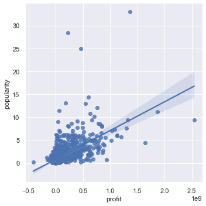

```python
# popularity correlated to profits

sns.lmplot(x='profit', y='popularity', data=df);
from scipy import stats
stats.pearsonr(df['profit'], df['popularity'])
```

> From the data, popularity of a movie is positively correlated to the amount of profits earned by that movie with a coefficient of 0.6214 which is a strong relationship

### Research Question 6 : Which year has the highest profits?

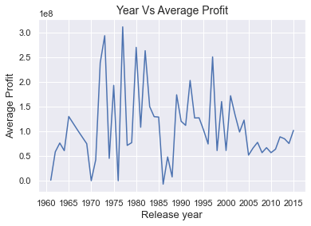

```python
df.groupby('release_year')['profit'].mean().plot(xticks = np.arange(1960,2016,5))

#setup the title and labels of the figure.
plt.title("Year Vs Average Profit",fontsize = 14)
plt.xlabel('Release year',fontsize = 13)
plt.ylabel('Average Profit',fontsize = 13)

#setup the figure size.
sns.set(rc={'figure.figsize':(10,10)})
sns.set_style("whitegrid")
```

### Research Question 7: Which year has the highest release of movies?

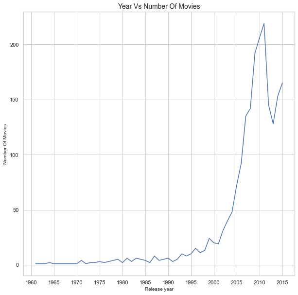

```python
#group data according to their release year and count the total number of movies in each year and plot.
df.groupby('release_year').count()['id'].plot(xticks = np.arange(1960,2016,5))

sns.set(rc={'figure.figsize':(10,5)})
plt.title("Year Vs Number Of Movies",fontsize = 14)
plt.xlabel('Release year',fontsize = 10)
plt.ylabel('Number Of Movies',fontsize = 10)

sns.set_style("darkgrid")
```

### Reasearch Question 8: Top 10 Production Companies With Higher Number Of Releases?

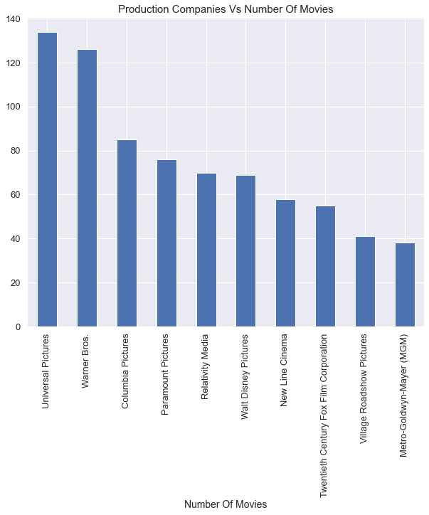

```python
def count_genre(x):
    #concatenate all the rows of the genres.
    df_plot = df[x].str.cat(sep = '|')
    data_c = pd.Series(df_plot.split('|'))
    #counts each of the genre and return.
    cnt = data_c.value_counts(ascending=False)
    return cnt

pdtn_cpy = count_genre('production_companies')

#plot the barchart.
pdtn_cpy.iloc[:10].plot(kind='bar',figsize=(10,8),fontsize=13)
plt.title("Production Companies Vs Number Of Movies",fontsize=15)
plt.xlabel('Number Of Movies',fontsize=14)
sns.set_style("whitegrid")
```

> The universal pictures released the highest number of movies

### Research Question 9: Which genres have the highest releases of movies?

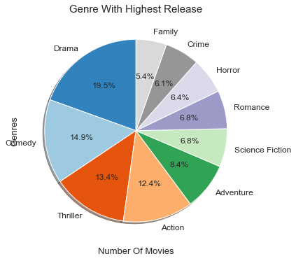

```python
ttl_genre = count_genre('genres')
#plot a piechart
ttl_genre.iloc[:10].plot(kind= 'pie',figsize = (13,6),fontsize=12,
        colormap='tab20c',autopct='%1.1f%%', shadow=True, startangle=90) #for beauty

plt.title("Genre With Highest Release",fontsize=15)
plt.xlabel('Number Of Movies',fontsize=13)
plt.ylabel("Genres",fontsize= 13)
sns.set_style("whitegrid")
```

> Drama movies had the highest releases

### Research Question 10: What Kind Of Properties Are Associated With Movies With High Revenue?

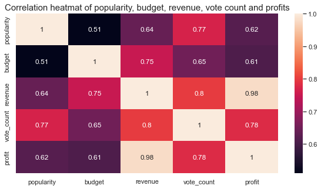

```python
df1 = df.drop(['id','release_year','runtime','vote_average'], axis=1, inplace=False)
corma= df1.corr().round(2)
sns.heatmap(corma, annot=True);
plt.title('Correlation heatmat of popularity, budget, revenue, vote count and profits', fontsize=15)
```

> Profit, vote count, revenue, budget, and popularity are moderately and strongly correlated with each other.

> Most especially is the Profits and Revenue(0.98), with vote count and revenue being next(0.8).

### Research Question 11 : Top 10 Directors Who Directs most Movies?

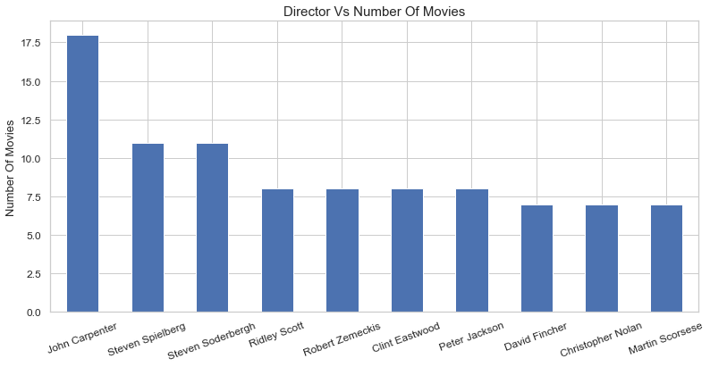

```python
count_director_movies = count_genre('director')

#plot a barchart
count_director_movies.iloc[:10].plot(kind='bar',figsize=(13,6),fontsize=12)

#create the title and the labels
plt.title("Director Vs Number Of Movies",fontsize=15)
plt.xticks(rotation=20)
plt.ylabel("Number Of Movies",fontsize= 13)
sns.set_style("whitegrid")
```

> Director John Carpenter directed most movies during the period

### Research Question 12: How is popularity trending over time?

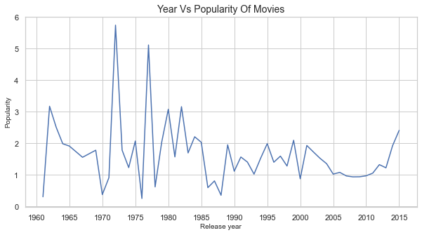

```python
#group data according to their release year and find the mean of the popularity  in each year and plot.
df.groupby('release_year')['popularity'].mean().plot(xticks = np.arange(1960,2016,5))

sns.set(rc={'figure.figsize':(10,5)})
plt.title("Year Vs Popularity Of Movies",fontsize = 14)
plt.xlabel('Release year',fontsize = 10)
plt.ylabel('Popularity',fontsize = 10)

sns.set_style("darkgrid")
```

> 1972 had the highest popularity of movies followed by 1977, after which there was relatively lower popular movies in the subsequent years with some rising in popularity from 2010 to 2015

## Conclusions

> The movie with the highest profit is "Avatar" and lowest profit is "The Warrior's Way"\ The movie with the highest budget is "The Warrior's Way", highest runtime is "Band of Brothers" and most popularity is "Jurassic World"\ Popularity of a movie has a high linear relationship with profits earned.\ Although movies made in 2011 were the most, movies made in 1977 gained more profits on the average.\ Dramas were most released and the Universal Pictures relesed the most movies. Also John Carpenter directed most movies during the period.\ Vote count is also highly correlated to revenues earned.\ Although recent movies are gaining popularity, movies made in 1972 had massive popularity

### Limitations

> The data contained many missing values which were mostly qualitative so it was difficult trying to fill them, hence I had to drop them. Though they might have affected my analysis and conclusions in a signficant way